# Worksheet 5a

2023-02-23

Questions are below. My solutions are below all the question parts for a question; scroll down if you get stuck. There might be extra discussion below that for some of the questions; you might find that interesting to read, maybe after tutorial.

For these worksheets, you will learn the most by spending a few minutes thinking about how you would answer each question before you look at my solution. There are no grades attached to these worksheets, so feel free to guess: it makes no difference at all how wrong your initial guess is!

Note: as I write this (the Thursday night of reading week in 2023), we have talked about in lecture the sign test (the Thursday before reading week), but not yet the normal quantile plot (this will be the Tuesday after reading week, and is fair game for the midterm). So you may want to read ahead.

Looking a bit further ahead: there is no assignment due the weekend of our midterm, so this worksheet has a “non-assignment” number; Worksheet 6 will be for tutorial on March 6, and will go with Assignment 6, which will be due on March 12.

# 1 Bidri

The production of Bidri is a traditional craft of India. Bidri wares (bowls, vessels, and so on) are cast from an alloy containing primarily zinc along with some copper. Consider the observations on copper content (%) for a sample of Bidri artifacts in London’s Victoria and Albert Museum, contained in http://ritsokiguess.site/datafiles/bidri.csv.

1. Read in and display (some of) the data.
2. Make a suitable plot to assess whether these values come from a normal distribution.
3. What do you conclude about normality from your plot? (I see two pieces of relevant evidence.)
4. Why do you think a researcher would favour a sign test over a $t$-test for these data? Explain briefly.
5. The copper content of other Bidri ware has been found to be 4 (percent). Test whether the Bidri ware that ended up at this museum comes from a population with a different *median* percentage of copper. What do you conclude, in the context of the data?
6. Find a 90% confidence interval for the median copper content (of the artifacts from which these are a sample).
7. Estimate (by simulation) and plot the bootstrap sampling distribution of the sample mean for these data, and explain why this offers further support for not doing a $t$-test here.

My solutions:

The production of Bidri is a traditional craft of India. Bidri wares (bowls, vessels, and so on) are cast from an alloy containing primarily zinc along with some copper. Consider the observations on copper content (%) for a sample of Bidri artifacts in London’s Victoria and Albert Museum, contained in http://ritsokiguess.site/datafiles/bidri.csv.

1. Read in and display (some of) the data.

Solution

The usual:

```r
my_url <- "http://ritsokiguess.site/datafiles/bidri.csv"
bidri <- read_csv(my_url)
bidri
```

| copper |
| --- |
| 2.0 |
| 2.4 |
| 2.5 |
| 2.6 |
| 2.6 |
| 2.7 |
| 2.7 |
| 2.8 |
| 3.0 |
| 3.1 |

[output cut: 14 more lines]

$\blacksquare$

2. Make a suitable plot to assess whether these values come from a normal distribution.

Solution

You are probably thinking about one of these:

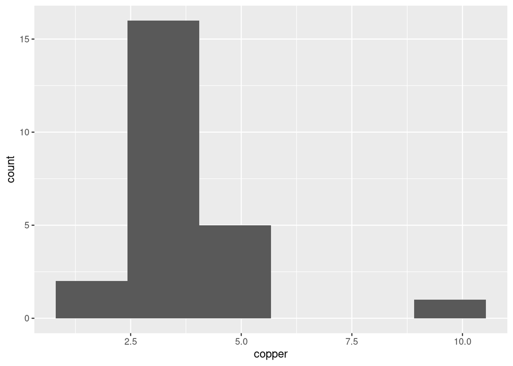

```r
ggplot(bidri, aes(x = copper)) + geom_histogram(bins = 6)
```

This has an upper outlier, by the looks of it, so we could use more bins to get a sense of the rest of the distribution (since a number of the bins will be empty):

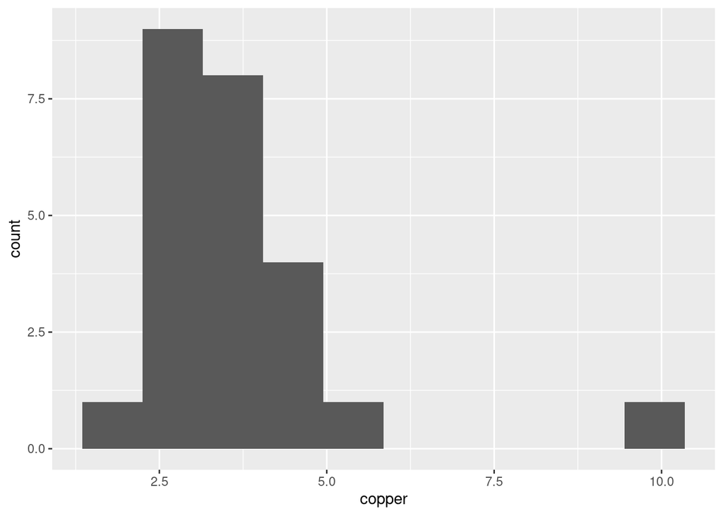

```r
ggplot(bidri, aes(x = copper)) + geom_histogram(bins = 10)
```

Or maybe a one-sample boxplot:

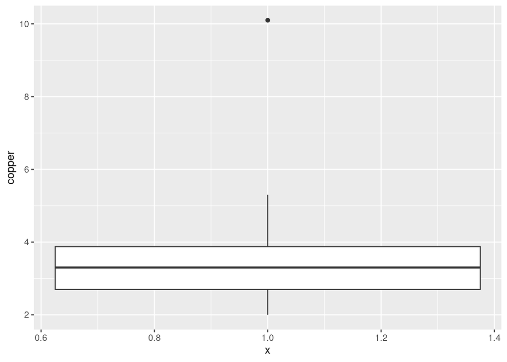

```r
ggplot(bidri, aes(x = 1, y = copper)) + geom_boxplot()
```

We are primarily interested in normality, so the best plot is in fact a normal quantile plot:

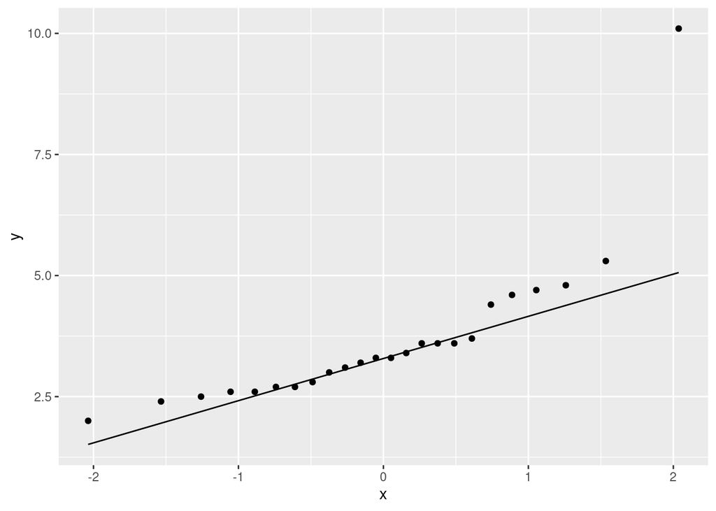

```r
ggplot(bidri, aes(sample = copper)) + stat_qq() + stat_qq_line()
```

$\blacksquare$

3. What do you conclude about normality from your plot? (I see two pieces of relevant evidence.)

Solution

There is a clear outlier at the upper end, one copper value that is way bigger than the others. If you look carefully at the normal quantile plot, you also see that the lowest few observations are too bunched up (above the line), and the highest few are too spread out (also above the line), and so the distribution is right-skewed as well as having an outlier. Thus the distribution is definitely not normal in shape, because of the outlier and because of the skewness.

If you drew one of the other graphs, the outlier is clear, but the skewness less so: the boxplot has a longer upper whisker as well as the outlier, and the histogram (the one with 10 bins) has some evidence of a long right tail in the body of observations separate from the outlier. But you have to work a bit harder to see it.

$\blacksquare$

4. Why do you think a researcher would favour a sign test over a $t$-test for these data? Explain briefly.

Solution

The issue is one of whether the data are sufficiently close to normality given the sample size. We said just now that the data are not very close to being normal, but the sample size of 24 is fairly large. I would say that the outlier is so extreme that even a sample size of 24 is not enough to overcome it.

Extra thoughts: If we didn’t have the outlier but just the skewness, I think an $n$ of 24 would be fine, since the skewness by itself is not extreme, but the outlier is a long way off from the other data. This is one of those situations (upper-end outlier or right-skewness) that taking logs might also help with,[^1] because it will bring the extreme high value down towards the rest of the data. If you were to go this way, you’d create a new column with the log-copper values in it, and then make a normal quantile plot of *those*, then make a call about sufficient normality.

$\blacksquare$

5. The copper content of other Bidri ware has been found to be 4 (percent). Test whether the Bidri ware that ended up at this museum comes from a population with a different *median* percentage of copper. What do you conclude, in the context of the data?

Solution

Make sure you have installed `smmr` following the instructions in the lecture notes (*outside* of the work you hand in, since you only need to do that once, not every time you re-knit your assignment), and loaded it somewhere, preferably *inside* your notebook, because you will need it for knitting/previewing to work.[^2]

This is a test for a median, so a sign test is the thing:

```r
sign_test(bidri, copper, 4)
```

```
## $above_below
## below above
##    18     6
##
## $p_values
##   alternative    p_value
## 1       lower 0.01132792
## 2       upper 0.99669462
## 3   two-sided 0.02265584
```

We are testing that the median is *different* from 4, so a *two-sided* P-value is the right one, which is 0.023. This is less than 0.05, so we conclude that the median copper content of the Bidri ware of which these artifacts are a sample is indeed different from 4.

Extra: I didn’t ask, but you could look at the table of aboves and belows to see that 18 of the 24 artifacts had a copper content below 4, and only 6 were above 4. This looks unbalanced enough to reject 4 as a possible median, and also suggests that these artifacts come from a population with copper content *below* 4 rather than above. See next part.

$\blacksquare$

6. Find a 90% confidence interval for the median copper content (of the artifacts from which these are a sample).

Solution

`ci_median`. Don’t forget to ask for a 90% interval rather than the default 95%:

```r
ci_median(bidri, copper, conf.level = 0.90)
```

```
## [1] 2.805859 3.597070
```

Between 2.81 and 3.60 percent (about two decimals is good[^3]). This is below 4, supporting what I said in the Extra to the previous part.

$\blacksquare$

7. Estimate (by simulation) and plot the bootstrap sampling distribution of the sample mean for these data, and explain why this offers further support for not doing a $t$-test here.

Solution

I’m saving mine, because I want to show you two plots, but you don’t need to (you could just go on and make the plot you want):

```r
tibble(sim = 1:1000) %>%
  rowwise() %>%
  mutate(my_sample = list(sample(bidri$copper, replace = TRUE))) %>%
  mutate(my_mean = mean(my_sample)) -> d
d
```

| sim | my_sample | my_mean |
| --- | --- | --- |
| 1 |  | 3.620833 |
| 2 |  | 4.045833 |
| 3 |  | 3.470833 |
| 4 |  | 3.412500 |
| 5 |  | 3.595833 |
| 6 |  | 3.587500 |
| 7 |  | 3.754167 |
| 8 |  | 4.041667 |
| 9 |  | 4.150000 |
| 10 |  | 3.870833 |

[output cut: 990 more lines]

The standard plot we have drawn for these is a histogram:

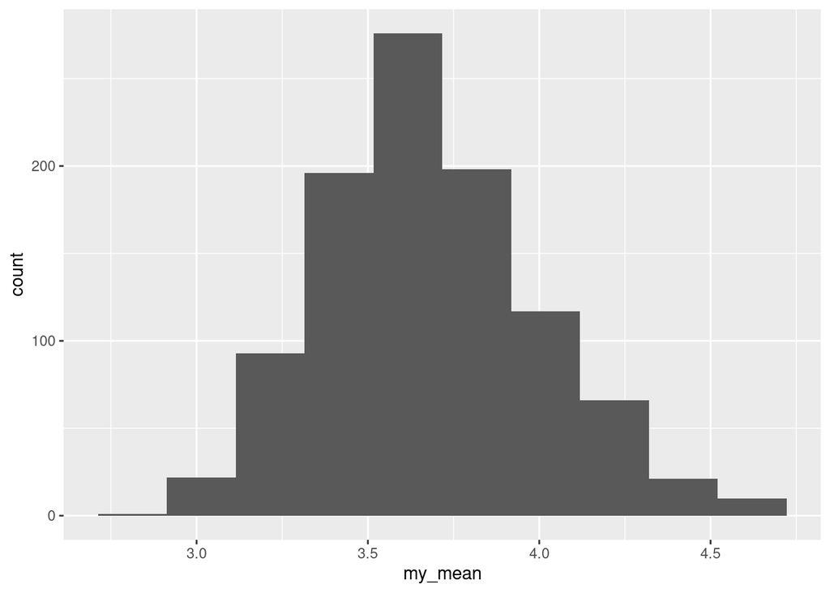

```r
ggplot(d, aes(x = my_mean)) + geom_histogram(bins = 10)
```

but if you think a bit, you’ll realize that we specifically care about whether this has a normal distribution or not, so a better plot would be a normal quantile plot:

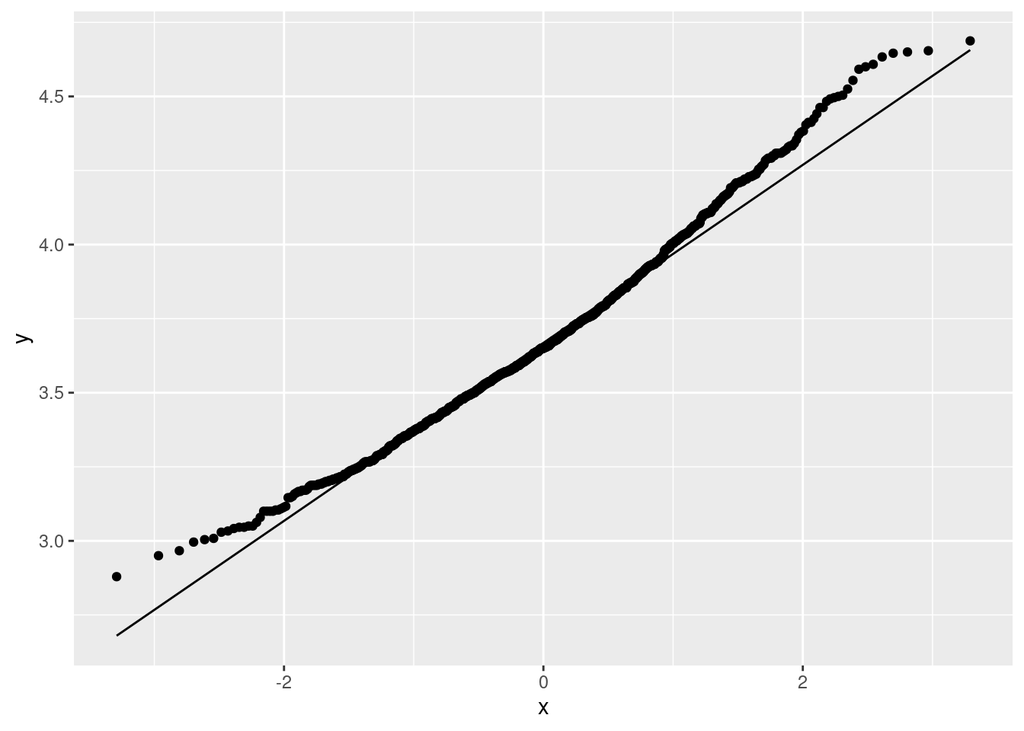

```r
ggplot(d, aes(sample = my_mean)) + stat_qq() + stat_qq_line()
```

Really, a normal quantile plot is better, but either a histogram or a normal quantile plot, properly drawn, is good here. (Or even a one-sample boxplot, which ought to be enough to show the skewness.)

Whichever plot you drew, this one also has a right-skewed distribution (and is not normal), indicating that the sample size of 24 was *not* large enough to overcome the effect of that extreme outlier. I think this is clearer on the normal quantile plot: even though the points are close to the line, there is a very clear pattern of bunched up at the bottom and spread out at the top that indicates a right skew. If the points were that close to the line but not showing such a clear pattern, I would be happy, but with such a pattern, there is a problem.

As a result, the $t$-test is not to be trusted, and we should therefore use a sign test.

Extra: my understanding is that outliers are in general a bigger problem for $t$-tests than skewness is. Unless the skewness is very pronounced, a decent sample size will get rid of its influence, but the same may not be true for outliers, particularly extreme ones. I had an example with a pronounced outlier and long tails. The latter, if that’s all there was, would be overcome with a reasonably large sample, but even a sample of size 300 was not big enough to overcome the effects of the outlier.

$\blacksquare$

[^1]: As on that worksheet.
[^2]: In my case, I have a separate notebook called “packages” that I include every time which loads all the packages I might want to use. The way to do that is to add a code chunk somewhere near the top of your document. Edit the top line so that it reads `r, child="packages.Rmd"`, where `packages.Rmd` represents the name of the notebook in which you have loaded all your packages. If your file has a different name, use that here. Then leave the actual chunk itself *empty*. This reads in and runs all the code in the “child” notebook and includes the code and output in your main document. I use this same idea when making assignments: each question is in a different file, and I bring them into an assignment as child notebooks like this.
[^3]: The data values are given to one decimal; look back and see. Going to one more decimal is fine, since we are talking about a kind of average, but you may also recall that the endpoints of a confidence interval for the *median* must be data values, since the P-value of a sign test only changes (when you change the null median) as you pass a data value, and thus change the number of values above and below. Thus the end points of this confidence interval are actually 2.8 and 3.6, and are only not given as exactly that because the bisection only works to a certain accuracy.